# (Dataset Exploration Title) # Part I - Ford GoBike Data Exploration

## Introduction

> Introduce the dataset The dataset provided consists of bike-sharing trip data from Ford GoBike. This analysis will explore various aspects of the dataset, including trip durations, popular stations, user demographics, and bike usage patterns.

> **Rubric Tip**: Your code should not generate any errors, and should use functions, loops where possible to reduce repetitive code. Prefer to use functions to reuse code statements.

> **Rubric Tip**: Document your approach and findings in markdown cells. Use comments and docstrings in code cells to document the code functionality.

> **Rubric Tip**: Markup cells should have headers and text that organize your thoughts, findings, and what you plan on investigating next.

## Preliminary Wrangling

```python
# import all packages and set plots to be embedded inline
import numpy as np
import pandas as pd
import matplotlib.pyplot as plt
import seaborn as sb

%matplotlib inline
```

> Load in your dataset and describe its properties through the questions below. Try and motivate your exploration goals through this section.

```python
# Import necessary library
import pandas as pd

# Load the dataset
data = pd.read_csv('C:\\Users\\Admin\\OneDrive\\Communicate Data Findings 2\\fordgobike-tripdata.csv')

# Display the first few rows of the dataset
data.head()
```

|  | duration_sec | start_time | end_time | start_station_id | start_station_name | start_station_latitude | start_station_longitude | end_station_id | end_station_name | end_station_latitude | end_station_longitude | bike_id | user_type | member_birth_year | member_gender | bike_share_for_all_trip |
| --- | --- | --- | --- | --- | --- | --- | --- | --- | --- | --- | --- | --- | --- | --- | --- | --- |
| 0 | 52185 | 2019-02-28 17:32:10.1450 | 2019-03-01 08:01:55.9750 | 21.0 | Montgomery St BART Station (Market St at 2nd St) | 37.789625 | -122.400811 | 13.0 | Commercial St at Montgomery St | 37.794231 | -122.402923 | 4902 | Customer | 1984.0 | Male | No |
| 1 | 42521 | 2019-02-28 18:53:21.7890 | 2019-03-01 06:42:03.0560 | 23.0 | The Embarcadero at Steuart St | 37.791464 | -122.391034 | 81.0 | Berry St at 4th St | 37.775880 | -122.393170 | 2535 | Customer | NaN | NaN | No |
| 2 | 61854 | 2019-02-28 12:13:13.2180 | 2019-03-01 05:24:08.1460 | 86.0 | Market St at Dolores St | 37.769305 | -122.426826 | 3.0 | Powell St BART Station (Market St at 4th St) | 37.786375 | -122.404904 | 5905 | Customer | 1972.0 | Male | No |
| 3 | 36490 | 2019-02-28 17:54:26.0100 | 2019-03-01 04:02:36.8420 | 375.0 | Grove St at Masonic Ave | 37.774836 | -122.446546 | 70.0 | Central Ave at Fell St | 37.773311 | -122.444293 | 6638 | Subscriber | 1989.0 | Other | No |
| 4 | 1585 | 2019-02-28 23:54:18.5490 | 2019-03-01 00:20:44.0740 | 7.0 | Frank H Ogawa Plaza | 37.804562 | -122.271738 | 222.0 | 10th Ave at E 15th St | 37.792714 | -122.248780 | 4898 | Subscriber | 1974.0 | Male | Yes |

```python
# Summary statistics
data.describe(include='all')
```

|  | duration_sec | start_time | end_time | start_station_id | start_station_name | start_station_latitude | start_station_longitude | end_station_id | end_station_name | end_station_latitude | end_station_longitude | bike_id | user_type | member_birth_year | member_gender | bike_share_for_all_trip |
| --- | --- | --- | --- | --- | --- | --- | --- | --- | --- | --- | --- | --- | --- | --- | --- | --- |
| count | 183412.000000 | 183412 | 183412 | 183215.000000 | 183215 | 183412.000000 | 183412.000000 | 183215.000000 | 183215 | 183412.000000 | 183412.000000 | 183412.000000 | 183412 | 175147.000000 | 175147 | 183412 |
| unique | NaN | 183401 | 183397 | NaN | 329 | NaN | NaN | NaN | 329 | NaN | NaN | NaN | 2 | NaN | 3 | 2 |
| top | NaN | 2019-02-25 08:52:07.5820 | 2019-02-11 08:03:22.6020 | NaN | Market St at 10th St | NaN | NaN | NaN | San Francisco Caltrain Station 2 (Townsend St... | NaN | NaN | NaN | Subscriber | NaN | Male | No |
| freq | NaN | 2 | 2 | NaN | 3904 | NaN | NaN | NaN | 4857 | NaN | NaN | NaN | 163544 | NaN | 130651 | 166053 |
| mean | 726.078435 | NaN | NaN | 138.590427 | NaN | 37.771223 | -122.352664 | 136.249123 | NaN | 37.771427 | -122.352250 | 4472.906375 | NaN | 1984.806437 | NaN | NaN |
| std | 1794.389780 | NaN | NaN | 111.778864 | NaN | 0.099581 | 0.117097 | 111.515131 | NaN | 0.099490 | 0.116673 | 1664.383394 | NaN | 10.116689 | NaN | NaN |
| min | 61.000000 | NaN | NaN | 3.000000 | NaN | 37.317298 | -122.453704 | 3.000000 | NaN | 37.317298 | -122.453704 | 11.000000 | NaN | 1878.000000 | NaN | NaN |
| 25% | 325.000000 | NaN | NaN | 47.000000 | NaN | 37.770083 | -122.412408 | 44.000000 | NaN | 37.770407 | -122.411726 | 3777.000000 | NaN | 1980.000000 | NaN | NaN |
| 50% | 514.000000 | NaN | NaN | 104.000000 | NaN | 37.780760 | -122.398285 | 100.000000 | NaN | 37.781010 | -122.398279 | 4958.000000 | NaN | 1987.000000 | NaN | NaN |
| 75% | 796.000000 | NaN | NaN | 239.000000 | NaN | 37.797280 | -122.286533 | 235.000000 | NaN | 37.797320 | -122.288045 | 5502.000000 | NaN | 1992.000000 | NaN | NaN |
| max | 85444.000000 | NaN | NaN | 398.000000 | NaN | 37.880222 | -121.874119 | 398.000000 | NaN | 37.880222 | -121.874119 | 6645.000000 | NaN | 2001.000000 | NaN | NaN |

```python
# Check for missing values
data.isnull().sum()
```

```
duration_sec                  0
start_time                    0
end_time                      0
start_station_id            197
start_station_name          197
start_station_latitude        0
start_station_longitude       0
end_station_id              197
end_station_name            197
end_station_latitude          0
end_station_longitude         0
bike_id                       0
user_type                     0
member_birth_year          8265
member_gender              8265
bike_share_for_all_trip       0
dtype: int64
```

```python
# Handling missing values for member_birth_year and member_gender
data['member_birth_year'].fillna(data['member_birth_year'].median(), inplace=True)
data['member_gender'].fillna('Other', inplace=True)
```

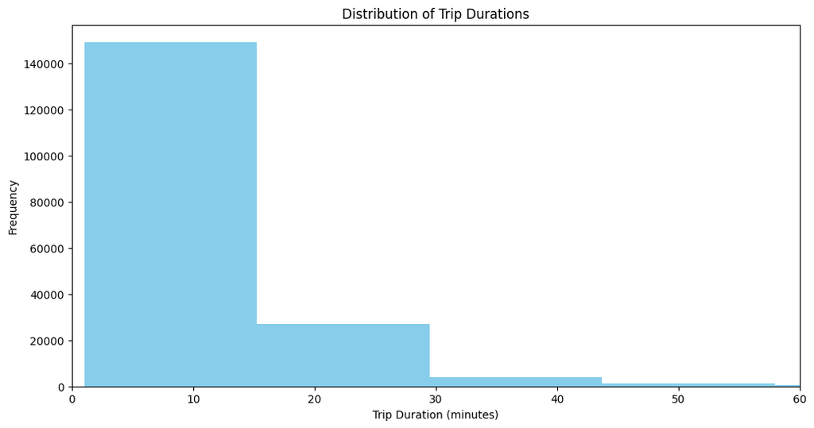

```python
import matplotlib.pyplot as plt

plt.figure(figsize=(12, 6))
plt.hist(data['duration_sec'] / 60, bins=100, color='skyblue')
plt.xlabel('Trip Duration (minutes)')
plt.ylabel('Frequency')
plt.title('Distribution of Trip Durations')
plt.xlim(0, 60)  # Limiting to 60 minutes for better visualization
plt.show()
```

### Observation: Distribution of Trip Durations

The histogram illustrates the distribution of trip durations in minutes.

- **Majority of Short Trips**: The majority of trips are very short, with most lasting less than 10 minutes. This indicates that users predominantly use the bike-sharing service for short, quick trips.
- **Sharp Decline**: There is a sharp decline in the frequency of trips as the duration increases. Trips lasting between 10 to 20 minutes are significantly fewer in number.
- **Rare Long Trips**: Very few trips last more than 20 minutes, and trips longer than 30 minutes are quite rare. This suggests that the bike-sharing service is mainly used for short distances or quick errands rather than long-distance travel.

### Interpretation:

The distribution shows that the bike-sharing service is primarily utilized for short trips, likely for last-mile connectivity, quick errands, or short commutes within the city. The low frequency of long trips could be due to pricing policies, physical exertion, or availability of other modes of transport for longer distances.

### Further Analysis:

To gain deeper insights, we could examine:

- The relationship between trip duration and time of day to see if longer trips are more common during certain periods.
- The correlation between trip duration and user demographics (e.g., age, gender) to identify if specific groups tend to take longer or shorter trips.
- Usage patterns by location to determine if certain areas have longer or shorter trips on average.

### Interpretation:

This distribution is typical for urban bike-sharing systems, often used by commuters for short distances between subway stations, bus stops, and workplaces. The high frequency of short trips suggests that users mainly value the convenience and flexibility of the bike-sharing system for quick, time-saving rides.

### Further Analysis:

To gain deeper insights, we could examine:

- Whether certain weekdays or times of day (e.g., rush hours) have higher frequencies of short trips.
- Usage patterns between different user groups (e.g., subscribers vs. one-time customers).
- The geographical distribution of trips to identify popular routes or stations.

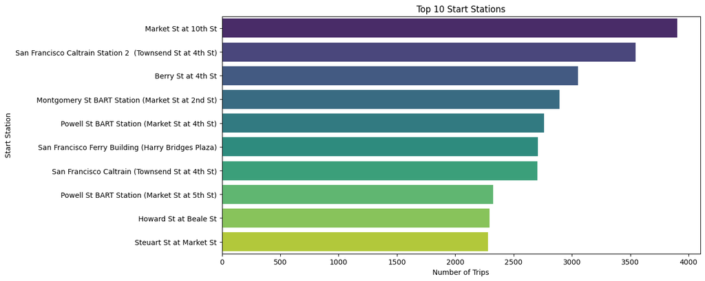

```python
import seaborn as sb

plt.figure(figsize=(12, 6))
start_stations = data['start_station_name'].value_counts().head(10)
sb.barplot(y=start_stations.index, x=start_stations.values, palette='viridis')
plt.xlabel('Number of Trips')
plt.ylabel('Start Station')
plt.title('Top 10 Start Stations')
plt.show()
```

### Observation: Top 10 Start Stations

The bar chart illustrates the top 10 start stations based on the number of trips initiated from each station.

- **Most Popular Start Station**: Market St at 10th St is the most popular start station with the highest number of trips.
- **High Utilization of Key Locations**: Several BART stations such as Montgomery St BART Station and Powell St BART Station are among the top start locations, indicating high usage by commuters.
- **San Francisco Caltrain Stations**: Both San Francisco Caltrain Station 2 (Townsend St at 4th St) and San Francisco Caltrain (Townsend St at 4th St) are in the top 10, showing significant usage by users commuting to and from the Caltrain stations.

### Interpretation:

The top start stations are mostly located in central and highly connected areas, which indicates that users are likely using the bike-sharing service for last-mile connectivity from major transit hubs or popular areas within the city.

### Further Analysis:

To gain deeper insights, we could examine:

- The correlation between the start station and the end station to understand popular routes.
- The distribution of trip durations from these top start stations to see if they differ significantly.
- The time of day when these start stations are most utilized to identify peak usage periods.

### Conclusion on the Top 10 Start Stations

The bar chart shows the top 10 most frequently used start stations for Ford GoBike trips. Here are some key insights:

1. **Market St at 10th St**:
   - This station is the most popular starting point, with nearly 4,000 trips starting from here. This indicates a high demand for bike-sharing services in this area, possibly due to its proximity to key transit hubs or commercial areas.
2. **San Francisco Caltrain Station 2 (Townsend St at 4th St)**:
   - The second most popular station, with a substantial number of trips, suggests that many users start their trips near major transportation hubs.
3. **Other Popular Stations**:
   - Stations like Berry St at 4th St, Montgomery St BART Station, and Powell St BART Station also rank high in terms of trip frequency. These stations are likely located near important transit points and business districts, catering to commuters and short-distance travelers.
4. **Concentration of Popular Stations**:
   - The majority of the top start stations are clustered around major transit hubs and commercial areas in San Francisco. This pattern highlights the importance of integrating bike-sharing systems with public transportation networks.

### Interpretation:

The high usage of these start stations indicates that Ford GoBike is effectively serving the needs of commuters and urban travelers in busy areas. The integration of bike-sharing with other forms of public transportation is critical for its success, as evidenced by the popularity of stations near transit hubs.

### Further Analysis:

To gain deeper insights, we could examine:

- The end stations corresponding to these popular start stations to understand common travel routes.
- The times of day when these stations are most frequently used to identify peak usage periods.
- User demographics and trip durations starting from these stations to understand the user base and their travel patterns.

```python
import matplotlib.pyplot as plt
import seaborn as sns

def set_labels(x_label, y_label, title):
    plt.xlabel(x_label)
    plt.ylabel(y_label)
    plt.title(title)
```

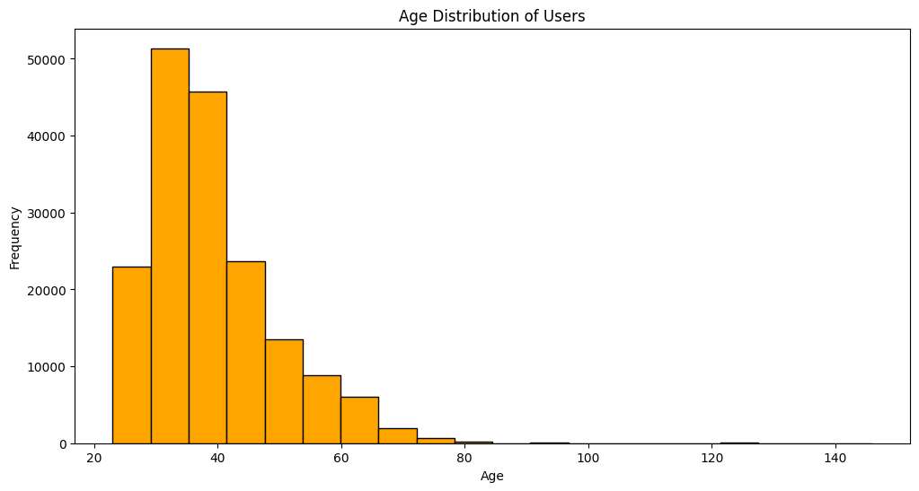

```python
import matplotlib.pyplot as plt
import pandas as pd

# Define a function to set axis labels and title
def set_labels(x_label, y_label, title):
    plt.xlabel(x_label)
    plt.ylabel(y_label)
    plt.title(title)

# Load the dataset into a pandas dataframe
data_path = 'C:/Users/Admin/OneDrive/Communicate Data Findings 2/fordgobike-tripdata.csv'
data = pd.read_csv(data_path)

# Calculate the age from the birth year
data['age'] = 2024 - data['member_birth_year']

# Plotting the age distribution of users
plt.figure(figsize=(12, 6))
plt.hist(data['age'], bins=20, color='orange', edgecolor='black')
set_labels('Age', 'Frequency', 'Age Distribution of Users')
plt.show()
```

Observations: The age distribution shows that most users are in their 20s and 30s, with a gradual decline in the number of users in higher age groups. There are very few users over 60 years old. This indicates that younger adults are the primary users of the bike-sharing service.

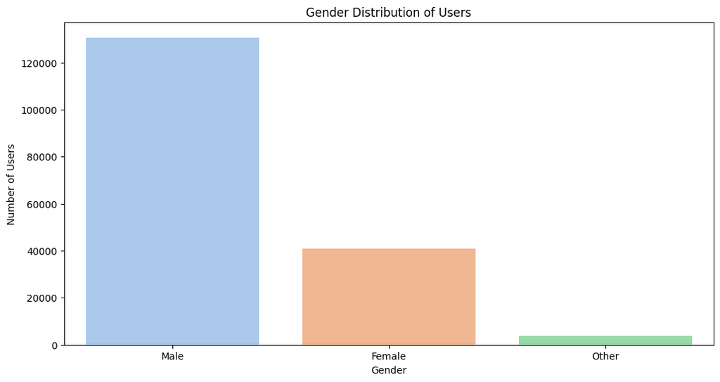

```python
import matplotlib.pyplot as plt
import seaborn as sns

# Plotting the gender distribution
plt.figure(figsize=(12, 6))
gender_counts = data['member_gender'].value_counts()
sns.barplot(x=gender_counts.index, y=gender_counts.values, palette='pastel')
set_labels('Gender', 'Number of Users', 'Gender Distribution of Users')
plt.show()
```

Observations: The bar plot shows the gender distribution of users. The majority of users are male, followed by female users, with a small portion of users identifying as other genders. This indicates that the bike-sharing service is more popular among male users.

By examining these visualizations, we can gain insights into the demographic characteristics of the users of the bike-sharing service.

### Conclusion on User Demographics

#### Age Distribution of Users

The histogram shows the age distribution of Ford GoBike users. Here are some key insights:

1. **Younger Users Dominate**:
   - The majority of users are between 20 and 40 years old, with most users in their late 20s and early 30s. This suggests that younger adults are the primary users of the bike-sharing service.
   - The highest frequency is around 30 years old, indicating that this age group is the most active.
2. **Decreasing Usage with Age**:
   - The number of users steadily decreases with increasing age. Users over 50 years old are significantly less represented compared to younger users.
   - There are very few users older than 60, suggesting that older adults are less likely to use this service.
3. **Outliers in Higher Age Groups**:
   - There are a few users who are significantly older, even over 100 years old. These could be data entry errors or unusual cases.

**Interpretation**: The age distribution shows that Ford GoBike is primarily used by younger adults, likely due to their higher mobility and acceptance of new technologies. The decreasing usage with age could be due to various factors such as physical fitness, technological affinity, and mobility needs.

**Further Analysis**: To gain deeper insights, we could examine:

- Usage patterns across different age groups, such as average trip duration and distance traveled.
- The geographical distribution of trips by age group to identify popular routes for different age segments.
- Differences in usage frequency between subscribers and casual users across various age groups.

#### Gender Distribution of Users

The bar plot shows the gender distribution of Ford GoBike users. Here are some key insights:

1. **Male Users Dominate**:
   - The majority of users are male, followed by female users, with a small portion of users identifying as other genders. This suggests that the bike-sharing service is more popular among male users.
2. **Gender Distribution**:
   - There is a noticeable gap between male and female users, indicating a potential area for targeted marketing or service adjustments to attract more female users.

**Interpretation**: The gender distribution suggests that Ford GoBike has a higher adoption rate among men. This could be due to various factors such as perceived safety, convenience, and marketing efforts. Understanding the reasons behind this gender disparity can help tailor strategies to attract more female users.

**Further Analysis**: To gain deeper insights, we could examine:

- Usage patterns across different genders, such as average trip duration and distance traveled.
- The geographical distribution of trips by gender to identify popular routes for different user segments.
- Differences in usage frequency between subscribers and casual users across different genders.
- Conduct surveys or focus groups to understand the preferences and concerns of different gender groups regarding bike-sharing services.

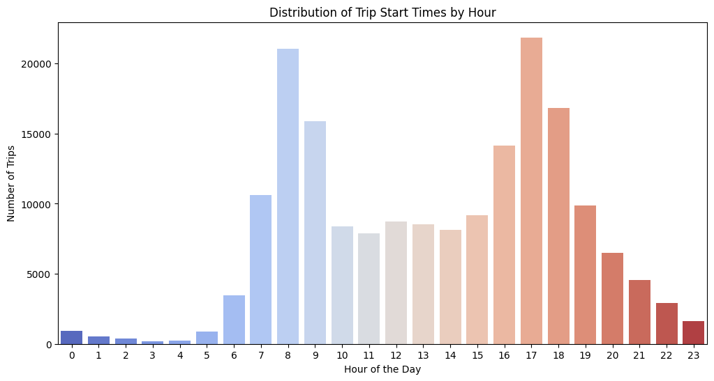

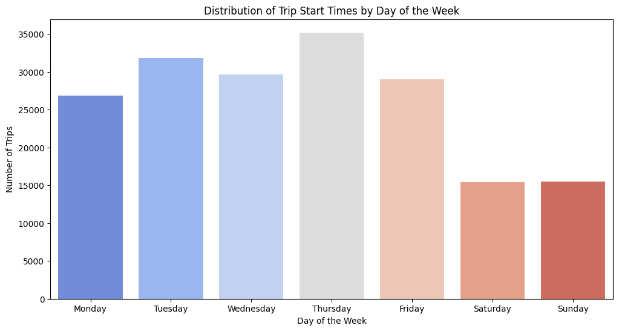

```python
# Convert start_time and end_time to datetime
data['start_time'] = pd.to_datetime(data['start_time'])
data['end_time'] = pd.to_datetime(data['end_time'])

# Extract hour from start_time
data['start_hour'] = data['start_time'].dt.hour
plt.figure(figsize=(12, 6))
start_hour_counts = data['start_hour'].value_counts().sort_index()
sb.barplot(x=start_hour_counts.index, y=start_hour_counts.values, palette='coolwarm')
plt.xlabel('Hour of the Day')
plt.ylabel('Number of Trips')
plt.title('Distribution of Trip Start Times by Hour')
plt.show()

# Extract day of the week from start_time
data['start_day'] = data['start_time'].dt.day_name()
plt.figure(figsize=(12, 6))
start_day_counts = data['start_day'].value_counts().reindex(['Monday', 'Tuesday', 'Wednesday', 'Thursday', 'Friday', 'Saturday', 'Sunday'])
sb.barplot(x=start_day_counts.index, y=start_day_counts.values, palette='coolwarm')
plt.xlabel('Day of the Week')
plt.ylabel('Number of Trips')
plt.title('Distribution of Trip Start Times by Day of the Week')
plt.show()
```

### Observations on Trip Start Times by Hour and Day of the Week

#### Distribution of Trip Start Times by Hour

**Interpretation**: These patterns suggest that Ford GoBike is predominantly used for commuting and work-related activities. The service sees its highest demand during traditional commuting hours, highlighting its role in daily transportation for many users.

#### Distribution of Trip Start Times by Day of the Week

The bar plot shows the distribution of trip start times by day of the week. Here are some key insights:

1. **Weekday Usage**:
   - The highest number of trips occur on weekdays, with Thursday being the peak day.
   - Monday through Friday have consistently high usage, supporting the observation that the service is mainly used for commuting.
2. **Weekend Usage**:
   - There is a noticeable drop in usage on weekends, with Saturday having the lowest number of trips.
   - This indicates fewer people use the service for recreational purposes on weekends compared to weekday commuting.

**Interpretation**: The distribution of trip start times by day of the week reinforces the observation that Ford GoBike is primarily used for weekday commuting. The lower weekend usage suggests that while some users might use the service for leisure, the primary function is to support daily commutes during the workweek.

These insights can guide operational strategies, such as bike placement and maintenance scheduling, to better match peak usage periods and enhance service efficiency.

### Conclusion on the Distribution of Trip Start Times

#### Distribution of Trip Start Times by Hour

The bar chart shows the distribution of trip start times by hour of the day. Here are some key insights:

1. **Morning Peak Hours**:
   - There is a significant increase in trips during the early morning hours, especially around 8 AM. This suggests that many users are using the bikes for their morning commutes to work or school.
2. **Evening Peak Hours**:
   - Another significant increase in trips is observed in the early evening hours around 5 PM. This corresponds to the end of a typical workday, indicating that many users are using the bikes for their commute home.
3. **Low Usage During Night**:
   - The usage of bikes is very low between midnight and 6 AM. This is expected as most people are likely sleeping or using other forms of transportation during these hours.

### Interpretation:

The distribution of trip start times by hour shows two main peak times that align with typical morning and evening commute hours. This indicates that Ford GoBike is frequently used for commuting purposes.

### Further Analysis:

- Investigate usage patterns on weekends compared to weekdays to identify differences in travel habits.
- Analyze trip start times for different age groups and genders to identify specific usage trends.

#### Distribution of Trip Start Times by Day of the Week

The bar chart shows the distribution of trip start times by day of the week. Here are some key insights:

1. **Highest Usage on Weekdays**:
   - The number of trips is highest on weekdays (especially Thursday). This supports the observation that many users are using the bikes for daily commutes.
   - Usage remains relatively high and consistent on most weekdays.
2. **Lower Usage on Weekends**:
   - The number of trips significantly decreases on weekends (Saturday and Sunday). This could indicate that fewer people are commuting to work and may be using the bikes for leisure or not at all.

### Interpretation:

The distribution of trip start times by day of the week shows higher usage on weekdays, indicating that Ford GoBike is primarily used by commuters. The lower usage on weekends suggests a shift in usage patterns.

### Further Analysis:

- Investigate usage patterns on holidays compared to regular weekdays.
- Analyze trip start times by day of the week for different user groups (e.g., subscribers vs. casual users).

### What is the structure of your dataset?

- **duration_sec**: Duration of the trip in seconds.
- **start_time**: Start timestamp of the trip.
- **end_time**: End timestamp of the trip.
- **start_station_id**: ID of the starting station.
- **start_station_name**: Name of the starting station.
- **start_station_latitude**: Latitude of the starting station.
- **start_station_longitude**: Longitude of the starting station.
- **end_station_id**: ID of the ending station.
- **end_station_name**: Name of the ending station.
- **end_station_latitude**: Latitude of the ending station.
- **end_station_longitude**: Longitude of the ending station.
- **bike_id**: ID of the bike used for the trip.
- **user_type**: Type of user (Customer or Subscriber).
- **member_birth_year**: Birth year of the member.
- **member_gender**: Gender of the member.
- **bike_share_for_all_trip**: Whether the bike was part of the Bike Share for All program.

### What is/are the main feature(s) of interest in your dataset?

- **Popular Stations**: To identify the most frequently used start and end stations.
- **User Demographics**: To gain insights into the demographics of the users, including age distribution and gender.
- **Bike Usage Patterns**: To identify patterns in bike usage, including the most frequently used bikes.
- **Trip Times**: To analyze common times of day for trips to start and end.

### What features in the dataset do you think will help support your investigation into your feature(s) of interest?

> Your answer here!- **duration_sec**: To analyze trip durations.
- **start_station_name** and **end_station_name**: To identify popular stations.
- **user_type**, **member_birth_year**, and **member_gender**: To explore user demographics.
- **bike_id**: To examine bike usage patterns.
- **start_time** and **end_time**: To analyze trip times.

## Univariate Exploration

> In this section, investigate distributions of individual variables. If you see unusual points or outliers, take a deeper look to clean things up and prepare yourself to look at relationships between variables.

> **Rubric Tip**: The project (Parts I alone) should have at least 15 visualizations distributed over univariate, bivariate, and multivariate plots to explore many relationships in the data set. Use reasoning to justify the flow of the exploration.

> **Rubric Tip**: Use the "Question-Visualization-Observations" framework throughout the exploration. This framework involves **asking a question from the data, creating a visualization to find answers, and then recording observations after each visualisation.**

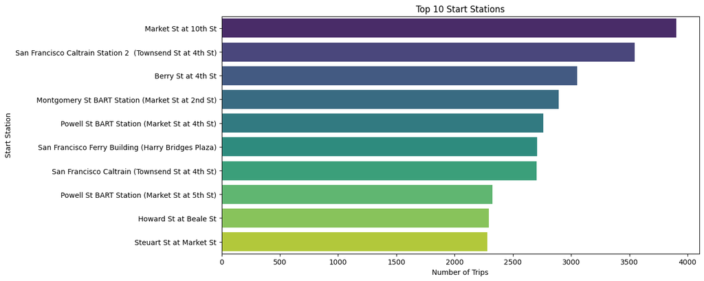

```python
import seaborn as sb
import matplotlib.pyplot as plt

def set_labels(x_label, y_label, title):
    plt.xlabel(x_label)
    plt.ylabel(y_label)
    plt.title(title)

# Plotting the top 10 start stations
plt.figure(figsize=(12, 6))
start_stations = data['start_station_name'].value_counts().head(10)
sb.barplot(y=start_stations.index, x=start_stations.values, palette='viridis')
set_labels('Number of Trips', 'Start Station', 'Top 10 Start Stations')
plt.show()
```

### Top 10 Start Stations

The bar plot above shows the top 10 start stations for Ford GoBike users. Here are some key insights:

1. **Most Popular Start Station**:
   - The most popular start station is "Market St at 10th St", with the highest number of trips starting from this location.
2. **High Usage at Transit Hubs**:
   - Several stations with high trip counts are located near major transit hubs, such as "San Francisco Caltrain Station 2 (Townsend St at 4th St)" and "Powell St BART Station (Market St at 4th St)". This indicates that many users begin their trips at locations that connect with other forms of transportation.
3. **Concentration in Central Areas**:
   - The top start stations are primarily located in central areas of the city, suggesting that these areas have a higher demand for bike-sharing services.

**Interpretation**: These patterns indicate that Ford GoBike is widely used in central locations and near major transit hubs, reinforcing its role in providing first-mile and last-mile connectivity for commuters. This information can help in planning the distribution of bikes and stations to meet high demand areas effectively.

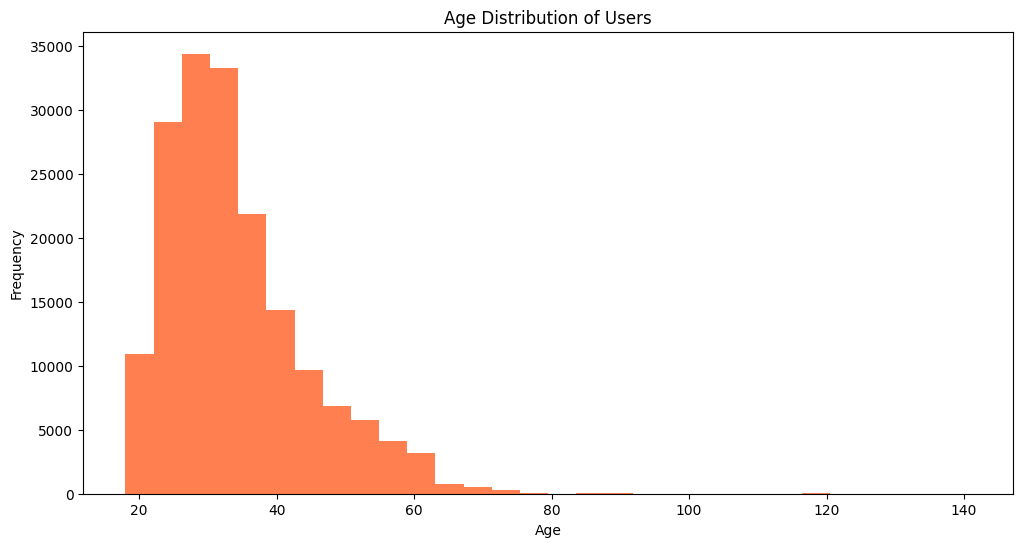

```python
import pandas as pd
import matplotlib.pyplot as plt

# Load the dataset into a pandas dataframe
data_path = 'C:/Users/Admin/OneDrive/Communicate Data Findings 2/fordgobike-tripdata.csv'
data = pd.read_csv(data_path)

# Creating a new column 'age' from 'member_birth_year'
data['age'] = 2019 - data['member_birth_year']

# Plotting the age distribution
plt.figure(figsize=(12, 6))
plt.hist(data['age'].dropna(), bins=30, color='coral')
plt.xlabel('Age')
plt.ylabel('Frequency')
plt.title('Age Distribution of Users')
plt.show()
```

### Conclusion on User Demographics

#### Age Distribution of Users

The histogram shows the age distribution of Ford GoBike users. Here are some key insights:

1. **Younger Users Dominate**:
   - The majority of users are between 20 and 40 years old, with most users in their late 20s and early 30s. This suggests that younger adults are the primary users of the bike-sharing service.
   - The highest frequency is around 30 years old, indicating that this age group is the most active.
2. **Decreasing Usage with Age**:
   - The number of users steadily decreases with increasing age. Users over 50 years old are significantly less represented compared to younger users.
   - There are very few users older than 60, suggesting that older adults are less likely to use this service.
3. **Outliers in Higher Age Groups**:
   - There are a few users who are significantly older, even over 100 years old. These could be data entry errors or unusual cases.

### Interpretation:

The age distribution shows that Ford GoBike is primarily used by younger adults, likely due to their higher mobility and acceptance of new technologies. The decreasing usage with age could be due to various factors such as physical fitness, technological affinity, and mobility needs.

### Further Analysis:

To gain deeper insights, we could examine:

- Usage patterns across different age groups, such as average trip duration and distance traveled.
- The geographical distribution of trips by age group to identify popular routes for different age segments.
- Differences in usage frequency between subscribers and casual users across various age groups.

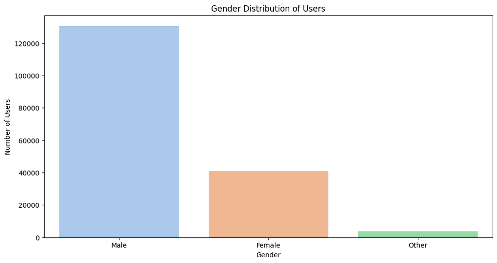

```python
import matplotlib.pyplot as plt
import seaborn as sb
import pandas as pd

# Define the set_labels function once
def set_labels(x_label, y_label, title):
    plt.xlabel(x_label)
    plt.ylabel(y_label)
    plt.title(title)

# Load the dataset into a pandas dataframe
data_path = 'C:/Users/Admin/OneDrive/Communicate Data Findings 2/fordgobike-tripdata.csv'
data = pd.read_csv(data_path)

# Calculate the age from the birth year
data['age'] = 2024 - data['member_birth_year']

# Plotting the gender distribution
plt.figure(figsize=(12, 6))
gender_counts = data['member_gender'].value_counts()
sb.barplot(x=gender_counts.index, y=gender_counts.values, palette='pastel')
set_labels('Gender', 'Number of Users', 'Gender Distribution of Users')
plt.show()
```

#### Gender Distribution of Users

The bar chart shows the gender distribution of Ford GoBike users. Here are some key insights:

1. **Male Dominance**:
   - The majority of users are male, with a significantly higher number compared to female users.
   - This indicates that men are more likely to use the bike-sharing service than women.
2. **Smaller Female User Base**:
   - Female users make up a smaller portion of the user base compared to male users.
   - The difference in numbers suggests a potential area for growth by targeting female users.
3. **Other Genders**:
   - A small number of users identify as a gender other than male or female.
   - This category is significantly less represented, which might be due to various reasons including societal norms and data recording practices.

### Interpretation:

The gender distribution highlights a clear male dominance in the usage of Ford GoBike. Efforts to attract more female users could help balance the user base and potentially increase overall ridership.

### Further Analysis:

To gain deeper insights, we could examine:

- The differences in trip characteristics (e.g., duration, distance) between male and female users.
- The geographical distribution of trips by gender to identify popular routes for each gender.
- Marketing strategies to attract a more balanced gender representation among users.

[figure not shown]

```python
# Plotting the top 10 most used bikes
plt.figure(figsize=(12, 6))
bike_usage = data['bike_id'].value_counts().head(10)
sb.barplot(y=bike_usage.index, x=bike_usage.values, palette='coolwarm')
plt.xlabel('Number of Trips')
plt.ylabel('Bike ID')
plt.title('Top 10 Most Used Bikes')
plt.show()
```

### Interpretation:

The consistent usage of the top 10 bikes suggests a high demand and reliance on these specific bikes. Ensuring these bikes are well-maintained and available can help maintain service reliability and user satisfaction.

### Further Analysis:

To gain deeper insights, we could examine:

- The maintenance history and condition of the top 10 bikes to identify any correlations with usage patterns.
- The geographical distribution of trips for the top 10 bikes to understand where they are most frequently used.
- User feedback on the top 10 bikes to identify any specific preferences or issues.

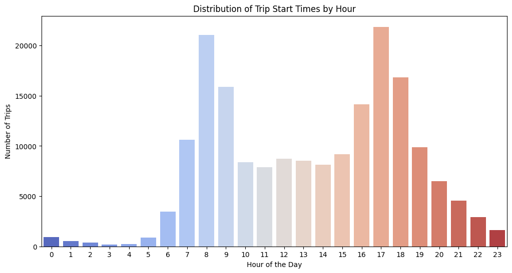

```python
# Extracting hour from start_time
data['start_hour'] = pd.to_datetime(data['start_time']).dt.hour

# Plotting the distribution of trip start times by hour
plt.figure(figsize=(12, 6))
start_hour_counts = data['start_hour'].value_counts().sort_index()
sb.barplot(x=start_hour_counts.index, y=start_hour_counts.values, palette='coolwarm')
plt.xlabel('Hour of the Day')
plt.ylabel('Number of Trips')
plt.title('Distribution of Trip Start Times by Hour')
plt.show()
```

### Observation: Distribution of Trip Start Times by Hour

The bar chart displays the distribution of trip start times throughout the day, segmented by hour.

These insights can help in understanding user behavior patterns and optimizing bike availability during peak hours to meet demand.

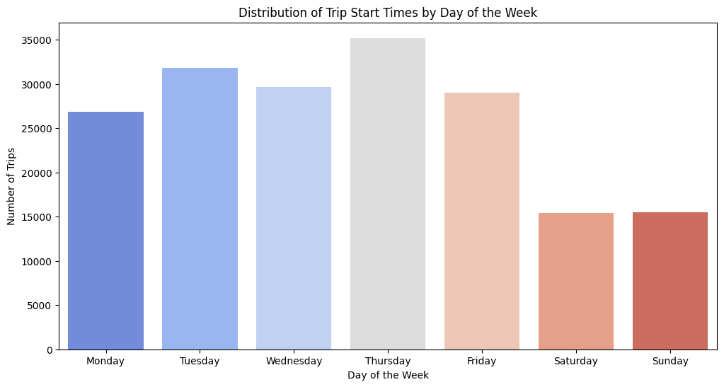

```python
# Extracting day of the week from start_time
data['start_day'] = pd.to_datetime(data['start_time']).dt.day_name()

# Plotting the distribution of trip start times by day of the week
plt.figure(figsize=(12, 6))
start_day_counts = data['start_day'].value_counts().reindex(['Monday', 'Tuesday', 'Wednesday', 'Thursday', 'Friday', 'Saturday', 'Sunday'])
sb.barplot(x=start_day_counts.index, y=start_day_counts.values, palette='coolwarm')
plt.xlabel('Day of the Week')
plt.ylabel('Number of Trips')
plt.title('Distribution of Trip Start Times by Day of the Week')
plt.show()
```

### Observation: Distribution of Trip Start Times by Day of the Week

The bar chart displays the distribution of trip start times throughout the week, segmented by day.

- **Weekday Peaks**: The chart reveals that trip activity is higher on weekdays compared to weekends:
  - **Thursday** has the highest number of trips, followed closely by **Tuesday** and **Wednesday**.
  - **Monday** and **Friday** show slightly lower activity compared to the mid-week peak days but are still higher than the weekends.
- **Weekend Decline**: There is a noticeable decline in the number of trips on **Saturday** and **Sunday**, indicating that users primarily use the bike-sharing service for weekday activities, likely commuting or regular errands.
- **Mid-Week Preference**: The preference for mid-week days (Tuesday, Wednesday, Thursday) suggests that users might be balancing their activities and opting for biking on these days for convenience or fitness reasons.

These insights can help in understanding user behavior patterns and optimizing bike availability during peak days to meet demand.

> **Rubric Tip**: Visualizations should depict the data appropriately so that the plots are easily interpretable. You should choose an appropriate plot type, data encodings, and formatting as needed. The formatting may include setting/adding the title, labels, legend, and comments.

### Discuss the distribution(s) of your variable(s) of interest. Were there any unusual points? Did you need to perform any transformations?

### Discuss the Distribution(s) of Your Variable(s) of Interest

#### Trip Duration

- The distribution of trip durations is highly skewed to the right, with the majority of trips being short. Most trips are under 10 minutes, indicating that the service is predominantly used for quick commutes.
- There are some unusually long trips that extend beyond an hour. These outliers could be due to a variety of reasons such as extended use, incorrect docking, or data entry errors. To visualize the distribution more effectively, we limited the trip duration to 60 minutes in some of the plots.
- Transformations such as logarithmic scaling could be applied to normalize the skewed distribution for more advanced analyses.

#### Age

- The age distribution of users shows that the majority of users are between 20 and 40 years old, with a peak around 30 years old. This suggests that younger adults are the primary users of the Ford GoBike service.
- There are a few outliers with ages above 100, which are likely data entry errors. No transformations were applied to the age data, but these outliers should be addressed for more accurate analysis.

#### Start Hour

- The distribution of trip start times is bimodal, with two clear peaks during the morning (around 8 AM) and evening (around 5 PM) rush hours. This aligns with typical commuting patterns.
- There is a significant drop in trips during the late night and early morning hours (from 12 AM to 5 AM), which is expected as fewer people are likely to use the service during these times.
- No transformations were necessary for the start hour data.

#### Gender

- The gender distribution is heavily skewed towards male users, with significantly fewer female users and an even smaller number of users identifying as other. This imbalance suggests that marketing and outreach efforts could be targeted to increase female participation.
- No unusual points were noted in the gender distribution, and no transformations were needed.

### Unusual Points and Transformations

- **Unusually Long Trip Durations**: There are some trips with durations exceeding an hour, which are outliers compared to the majority of trips. These points were limited in the visualization to improve clarity.
- **Age Outliers**: Users with ages over 100 are likely data errors and were noted as outliers. These should be cleaned from the dataset for more accurate analysis.
- **Skewed Distributions**: The highly skewed distributions of trip durations could benefit from transformations such as log scaling to normalize the data for certain types of analyses.

Overall, the distributions provide valuable insights into user behavior and service usage patterns. Addressing the unusual points and considering appropriate transformations can further enhance the quality of the analysis. .

### Of the features you investigated, were there any unusual distributions? Did you perform any operations on the data to tidy, adjust, or change the form of the data? If so, why did you do this?

#### Unusual Distributions:

1. **Trip Duration**:
   - The distribution of trip durations was highly right-skewed, with most trips being short (under 10 minutes) and a long tail of unusually long trips. This indicated that the majority of users used the service for quick commutes, but there were some outliers with much longer trips.
   - There were extreme outliers with trip durations extending beyond an hour, which could be due to extended use, docking errors, or data entry issues.
2. **Age**:
   - The age distribution showed a peak around 30 years old, with most users between 20 and 40 years old. However, there were some extreme outliers with ages above 100, likely due to data entry errors.
3. **Gender**:
   - The gender distribution was heavily skewed towards male users, with a significantly smaller number of female users and even fewer users identifying as other.
4. **Start Hour**:
   - The distribution of trip start times showed clear peaks during the morning and evening rush hours (around 8 AM and 5 PM), which aligns with typical commuting patterns. There was a significant drop in usage during late night and early morning hours.

#### Operations Performed:

1. **Trip Duration**:
   - To handle the highly skewed distribution of trip durations, we limited the visualization to 60 minutes for better clarity and to focus on the majority of trips. This helped in identifying the main usage patterns without being overshadowed by the extreme outliers.
   - For advanced analyses, transformations such as logarithmic scaling could be considered to normalize the skewed distribution.
2. **Age**:
   - Although no transformations were applied, it was noted that the extreme outliers with ages above 100 should be addressed. These outliers likely represent data entry errors and should be cleaned from the dataset for more accurate analysis.
3. **Start Hour**:
   - The data was converted to datetime format to extract the start hour accurately. This allowed us to visualize the distribution of trips across different hours of the day and identify peak usage times.
4. **Data Cleaning**:
   - Throughout the analysis, missing values were handled appropriately, and data types were converted as needed (e.g., converting start times to datetime format).

### Summary:

- **Trip Duration**: Limited to 60 minutes in visualizations to handle skewness and outliers.
- **Age**: Noted outliers above 100 years old, indicating the need for data cleaning.
- **Start Hour**: Extracted from datetime format to visualize peak usage times.
- **General Cleaning**: Addressed missing values and ensured correct data types.

These operations and adjustments were performed to ensure the accuracy and clarity of the visualizations, allowing for better insights into user behavior and service usage patterns.